# TP2: Extensions to linear models

Author

Lionel Hertzog

Published

July 31, 2026

## 1 Objectives

The aim of the practical coding session is to explore various extensions to the linear models:

1. Multiple covariable
2. Interactions
3. Variable transformation

For this practical we will work further with forest biomass data from the Vosges with an augmented dataset with additionnal variables.

## 2 Read the data

Load the `dat_tp2.csv` into R. Perform quick exploration of the dataset.

```r
here::i_am("practicals/tp2.qmd")
dat <- read.csv("../data/dat_tp2.csv")

head(dat)
```

```
     idp       mqd   biomass  zp reserutile troph_r       species
1 746162 0.3446880 348.55178 332       89.5 2.98077 Pin sylvestre
2 712867 0.2135135 238.30077 348       63.0 1.11424 Sapin pectiné
3 720620 0.2213249 134.87458 359       35.0 4.04955 Sapin pectiné
4 770767 0.1574642 117.60808 374       50.4 1.18779       Douglas
5 751199 0.3101397  74.84114 466       21.0 2.37592 Sapin pectiné
6 740332 0.2938409 249.62688 384       29.4 1.19309 Sapin pectiné
                            ownership
1                Forêts domaniales RF
2          Autres forêts publiques RF
3 Forêts privées et autres - Hors PSG
4   Forêts privées et autres - En PSG
5                Forêts domaniales RF
6   Forêts privées et autres - En PSG
```

Metadata:

- idp: plot id
- mqd: square root of the mean quadratic diameter, a proxy of stand maturity, in m.
- biomass: plot above and belowground tree biomass in tons of dry matter per hectare
- zp: elevation in m
- reserutile: water holding capacity of the soil in mm
- troph_r: soil fertility proxy from the flora from 0 (acid) to 11 (calcacerous)
- species: the dominant tree species in the plot
- ownership: the ownership status of the plot in 4 classes: Forêt domaniales - state forest, Autres forêts publiques - forest owned by local administrations, Forêts privées Hors PSG - private forest without management plans, Forêts privées En PSG - private forests with management plans

## 3 Multiple covariables

We will now explore various models fitted with multiple covariables.

These can be added to the model formula as follow:

```r
m <- lm(y ~ x1 + x2 + x3, ...)
```

1.1 Fit a linear model with the covariable *troph_r*, *reserutile* and *zp*, check if the model meet the assumptions using **DHARMa**.

1.2 From the fitted model, can you identify the most important covariable? If not, how would you do this?

**TipHint**

Check the scale function `scale` to put all covariables on the same scale.

1.3 Using the `predict_response` function from the **ggeffects** package, plot the regression line for the effect of troph_r under different levels of reserutile and zp. What do you see?

**TipHint**

Pass different covariables with specific values to the *terms* argument in `predict_response`, read the `predict_response` help page or check online.

2.1 Now fit a model with the covariable *troph_r* and *ownership*, interpret the reported regression coefficients (we assume that model checks are ok)

2.2 Plot the predicted biomass values for the different ownership classes and for varying values of soil fertility.

**TipHint**

Factor levels can also be passed to the *terms* argument of `predict_response`

2.3 Bonus: vary the contrasts settings of the *ownership* covariable, explore how it affects the regression coefficients.

## 4 Interactions

In models with multiple covariables, interactions between covariables can be added to account for changes in relation between the response and a given covariable along the gradient of another covariable.

Interactions are added to R formula using `x1*x2`.

1.1 Fit a model with an interaction between *troph_r* and *ownership*, write 2-3 sentences to interpret the various model coefficients.

1.2 Using `predict_response`, plot the regression lines for the effect of *troph_r* under the different *ownership* levels.

2.1 Fit the same model after scaling the *troph_r* variable, do you see the same results?

2.2 Fit and compare the estimated coefficients for (i) a model with *troph_r* and *zp* with an interaction between twe two, (ii) a model with the scaled *troph_r* and *zp* with an interaction with the two. How do you interpret the potential difference between the two models?

## 5 Non-linear relations

Linear model can also estimate non-linear relations through variable transformation (i.e. log) or the use of polynomes.

### 5.1 Variable transformation

A smooth fit on the biomass ~ zp relation tend to show a saturating relation between these variables

```r
ggplot(dat, aes(x=zp, y=biomass)) +
  stat_smooth() +
  labs(x = "Elevation (m)",
       y = "Biomass (t/ha)")
```

[output not shown]

1. Which function do you think would be adapted to this saturating relation?

**TipHint**

You can check various function passed to `stat_smooth` using this synthax:

```r
... +
  stat_smooth(method = "lm", formula = y ~ f(x)) +
  ...
```

Where `f` is a function.

2. Fit a model with the appropriate function applied to *zp*. This can be done either by transforming the variable in the data.frame:

```r
dat$zp_trans <- f(dat$zp)
```

Or by applying this function in the linear model formula:

```r
m <- lm(biomass ~ f(zp), dat)
```

3. Plot the predicted regression line with this model. Compare it with the fitted regression line from the untransformed model.

### 5.2 Polynomes

The relation between *mqd* and *biomass* seems to be hump-shaped:

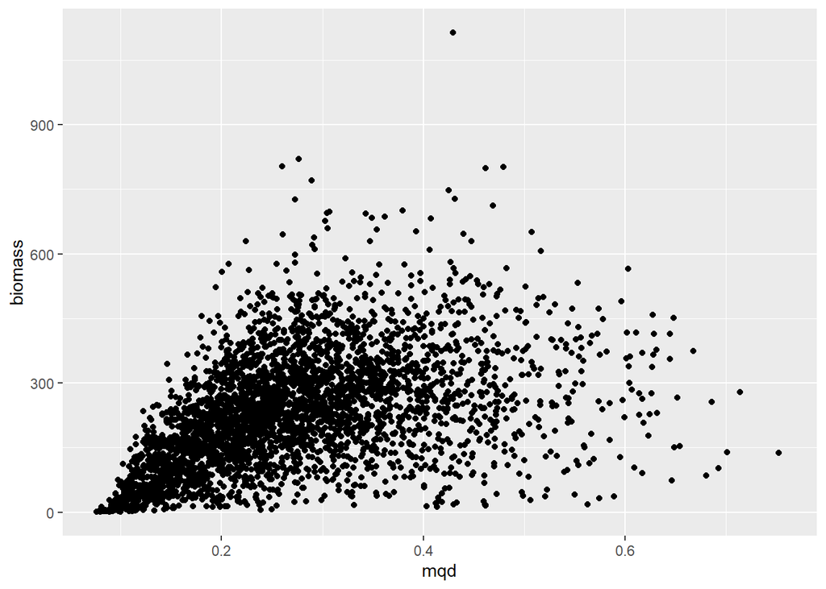

```r
ggplot(dat, aes(x=mqd, y=biomass)) +
  geom_point()
```

Polynomes can be added to lm as follow:

```r
m <- lm(y ~ x + I(x^2) + I(x^3) + ...)
```

1. Fit a linear model with *mqd* as a polynomial of degree 2. Compare the residuals from **DHARMa** with `plotResiduals` with a model without polynomial terms and with a model with a variable transformation. Is one of the three model more adequate?
2. Plot the regression line of the selected model.
3. Add an interaction term between *mqd* and ownership to study potential variation in the non-linear relation with ownership class. Remember to scale the *mqd* variable before fitting the model.
4. Plot the regression lines. Do you see something strange? How could you remedy this?